# Lab: Applied Bayesian Statistics

## Logit model

### The three parts of every GLM

All generalized linear models have three characteristic parts:

#### Family

- The family stipulates a stochastic process that can plausibly generate an outcome $y$
- This means we choose a pdf or pmf for $y$ given some parameters: $y_i \sim \text{f}(\theta_i, \psi)$
- The choice usually depends on the distributional properties of $y$

#### Linear component

- A linear model $y_i^{\ast} = \mathbf{x}_i^{\prime} \beta + \epsilon_i$
- The goal of inference is the estimation of $\beta$
- From, this, we can derive our *systematic component* or *linear predictor*, $\eta_i = \mathbf{x}_i^{\prime} \beta$

#### Inverse link function

- A function that transforms the systematic component $\eta_i$ such that it represents a characteristic *parameter* $\theta_i$ of the family
- $\theta_i = g^{-1}(\eta_i)$

### The logit model

The logit model is a popular model for binary outcomes.

- Family:
  $$y_i \sim
  \text{Bernoulli}(\pi_i)$$
- Linear component:
  $$y_i^{\ast} =
  \underbrace{\mathbf{x}_i^{\prime} \beta}_{\eta_i} +
  \underbrace{\epsilon_i}_{\sim \text{Logistic}(0, 1)}$$
- Inverse link function:
  $$\pi_i =
  \frac{\exp(\eta_i)}{1 + \exp(\eta_i)}$$

Thus, the logit model is given by

$$y_i \sim
\text{Bernoulli}\left(\frac{\exp(\eta_i)}{1 +
\exp(\eta_i)}\right)$$

where the $\beta$ vector is being estimated. Note that the parameters of the $\text{Logistic}(0, 1)$ error distribution are fixed and therefore need not be estimated.

### Context

In this exercise, we are interested in how the effect of socio-economic policy preferences and immigration policy preferences affected vote choices for the Greens in 2017.

The following are once again or focal predictors:

- `se_self` ranges from values (0) “less taxes and deductions, even if that means less social spending” to (10) “more social spending, even if that means more taxes and deductions”.
- `la_self` ranges from values (0) “facilitate immigration” to (10) “restrict immigration”.

### Data

We model respondents’ vote choices for the Greens (`vote_greens`), as a function of respondents’ pro-redistribution preferences (`se_self`) and anti-immigration preferences (`la_self`), each of which we interact with respondents’ gender. We also control for age (`age`) and East/West residence (`east`).

The model formula is given by

$$\mathtt{vote\_greens}_i = \\\beta_1 + \beta_2 \mathtt{la\_self}_i +
\beta_3 \mathtt{se\_self}_i + \\ \beta_4 \mathtt{fem}_i + \beta_5
\mathtt{east}_i + \beta_6 \mathtt{age}_i + \\ \beta_7
\mathtt{la\_self}_i \times \mathtt{fem}_i + \beta_8 \mathtt{se\_self}_i
\times \mathtt{fem}_i + \epsilon$$

## Fitting

### Choosing priors

Check the default priors for the logit model using `brms::get_prior()`.

Note that you must supply the model formula, the `data`, and the `family` of the model. For a logit model, we must set `family = bernoulli(link = "logit")`

```r
# Get default priors
default_priors_logit <- brms::get_prior(
  vote_greens ~                          # outcome
    la_self +                            # immigration preferences
    se_self +                            # redistribution preferences
    fem +                                # gender
    east +                               # east/west residence
    age +                                # age
    la_self:fem +                        # interaction term 1
    se_self:fem,
  data = gles,                          # data
  family = bernoulli(link = "logit")    # family and link
)
default_priors_logit
```

```
##                 prior     class         coef group resp dpar nlpar lb ub       source
##                (flat)         b                                               default
##                (flat)         b          age                             (vectorized)
##                (flat)         b        east1                             (vectorized)
##                (flat)         b         fem1                             (vectorized)
##                (flat)         b      la_self                             (vectorized)
##                (flat)         b la_self:fem1                             (vectorized)
##                (flat)         b      se_self                             (vectorized)
##                (flat)         b se_self:fem1                             (vectorized)
##  student_t(3, 0, 2.5) Intercept                                               default
```

### Define custom priors

Generate an object called `custom_priors_logit` with $\text{Normal(0,5)}$ priors for both intercept and slopes.

```r
custom_priors_logit <- c(
  brms::prior(normal(0, 5), class = b),          # normal slopes
  brms::prior(normal(0, 5), class = Intercept)   # normal intercept
)
custom_priors_logit
```

```
##         prior     class coef group resp dpar nlpar   lb   ub source
##  normal(0, 5)         b                            <NA> <NA>   user
##  normal(0, 5) Intercept                            <NA> <NA>   user
```

### Fitting the model

Fit the model using `brms::brm()`. Pass your custom priors from `custom_priors_logit` to the model.

Run the model with four chains for 2000 iterations each, discarding the first 1000 draws as warmup. Set the seed to todays date, `20231123L`.

*Note:* Model compilation and estimation may take a while.

```r
logit_brms <- brms::brm(
  vote_greens ~                          # outcome
    la_self +                            # immigration preferences
    se_self +                            # redistribution preferences
    fem +                                # gender
    east +                               # east/west residence
    age +                                # age
    la_self:fem +                        # interaction term 1
    se_self:fem,                         # interaction term 2
  data = gles,                           # data
  family = bernoulli(link = "logit"),    # family and link
  prior = custom_priors_logit,           # priors
  chains = 4L,                           # number of chains
  iter = 2000L,                          # number of iterations per chain
  warmup = 1000L,                        # number of warm-up samples per chain
  algorithm = "sampling",                # algorithm (HMC/NUTS)
  backend = "rstan",                     # backend (rstan)
  seed = 20231123L                       # seed
)
```

## Summarize and diagnose

### Model summary and generic diagnostics

Print the model summary and check `Rhat` for any signs of non-convergence.

```r
logit_brms
```

```
##  Family: bernoulli
##   Links: mu = logit
## Formula: vote_greens ~ la_self + se_self + fem + east + age + la_self:fem + se_self:fem
##    Data: gles (Number of observations: 1321)
##   Draws: 4 chains, each with iter = 2000; warmup = 1000; thin = 1;
##          total post-warmup draws = 4000
##
## Regression Coefficients:
##              Estimate Est.Error l-95% CI u-95% CI Rhat Bulk_ESS Tail_ESS
## Intercept       -1.27      0.48    -2.23    -0.32 1.00     2297     2897
## la_self         -0.16      0.05    -0.26    -0.06 1.00     2118     2456
## se_self          0.17      0.06     0.06     0.29 1.00     2454     2789
## fem1             1.17      0.63    -0.11     2.38 1.00     1682     2177
## east1           -0.78      0.24    -1.27    -0.31 1.00     3621     2654
## age             -0.02      0.00    -0.03    -0.01 1.00     4753     3152
## la_self:fem1    -0.05      0.07    -0.19     0.09 1.00     1986     2171
## se_self:fem1    -0.14      0.08    -0.30     0.02 1.00     2083     2435
##
## Draws were sampled using sampling(NUTS). For each parameter, Bulk_ESS
## and Tail_ESS are effective sample size measures, and Rhat is the potential
## scale reduction factor on split chains (at convergence, Rhat = 1).
```

### Visual diagnostics

Explore some visual diagnostics of your choice. See `help(mcmc_plot)` for types of plots.

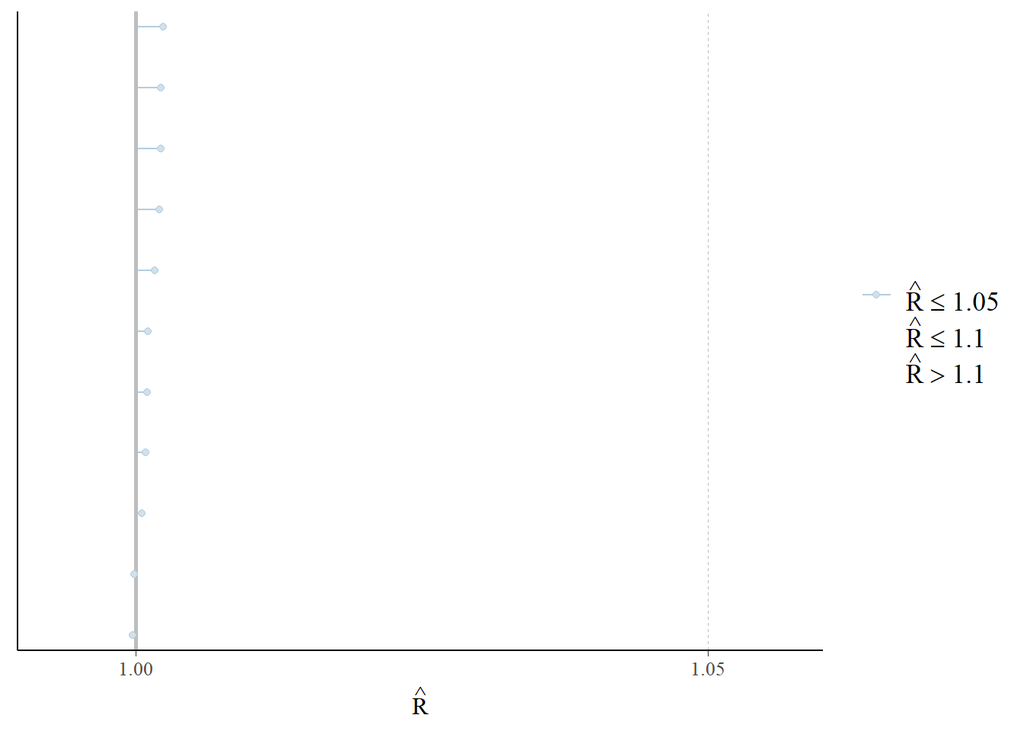

```r
brms::mcmc_plot(logit_brms, type = "rhat")  # Gelman-Rubin
```

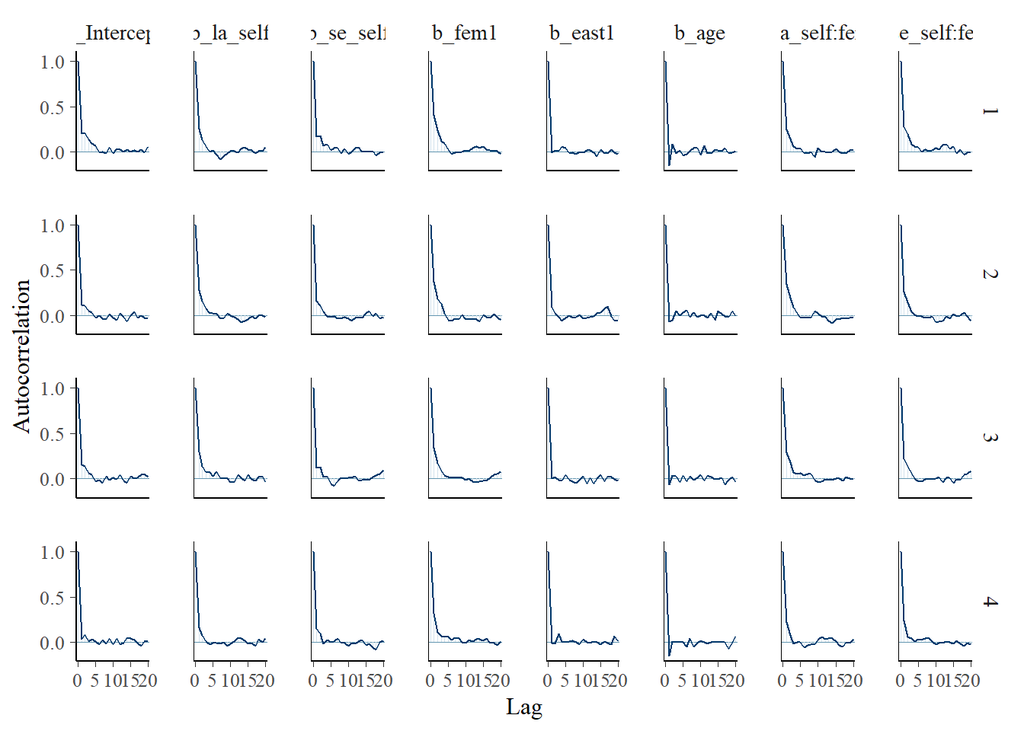

```r
brms::mcmc_plot(logit_brms, type = "acf")   # Autocorrelation
```

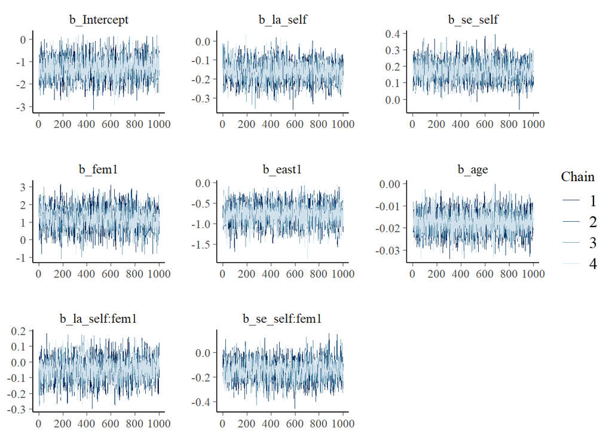

```r
brms::mcmc_plot(logit_brms, type = "trace") # Trace plots
```

### Algorithm-specific diagnostics

Use the `check_hmc_diagnostics()` function from the `rstan` package to check for algorithm-specific anomalies. Remember that we must extract the `stanfit` object nested in our `brmsfit` object via `logit_brms$fit`.

```r
rstan::check_hmc_diagnostics(logit_brms$fit)
```

```
##
## Divergences:
```

```
## 0 of 4000 iterations ended with a divergence.
```

```
##
## Tree depth:
```

```
## 0 of 4000 iterations saturated the maximum tree depth of 10.
```

```
##
## Energy:
```

```
## E-BFMI indicated no pathological behavior.
```

## Quantities of interest

Use `marginaleffects::plot_slopes()` to visualize the effects of (1) immigration preferences (`la_self`) and (2) socio-economic preferences (`se_self`), each conditional on respondents’ gender (`fem`), on the probability of voting for the Greens.

Interpret your findings.

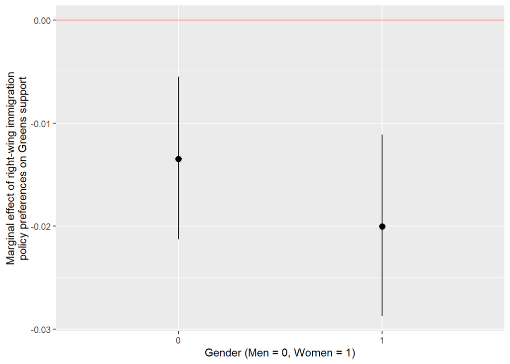

```r
marginaleffects::plot_slopes(logit_brms,
                             variable = "la_self",
                             condition = "fem") +
  ggplot2::geom_hline(yintercept = 0,
                     col = "red",
                     alpha = 0.5) +
  ggplot2::xlab("Gender (Men = 0, Women = 1)") +
  ggplot2::ylab(paste(
    "Marginal effect of right-wing immigration",
    "policy preferences on Greens support",
    sep = "\n"
  ))
```

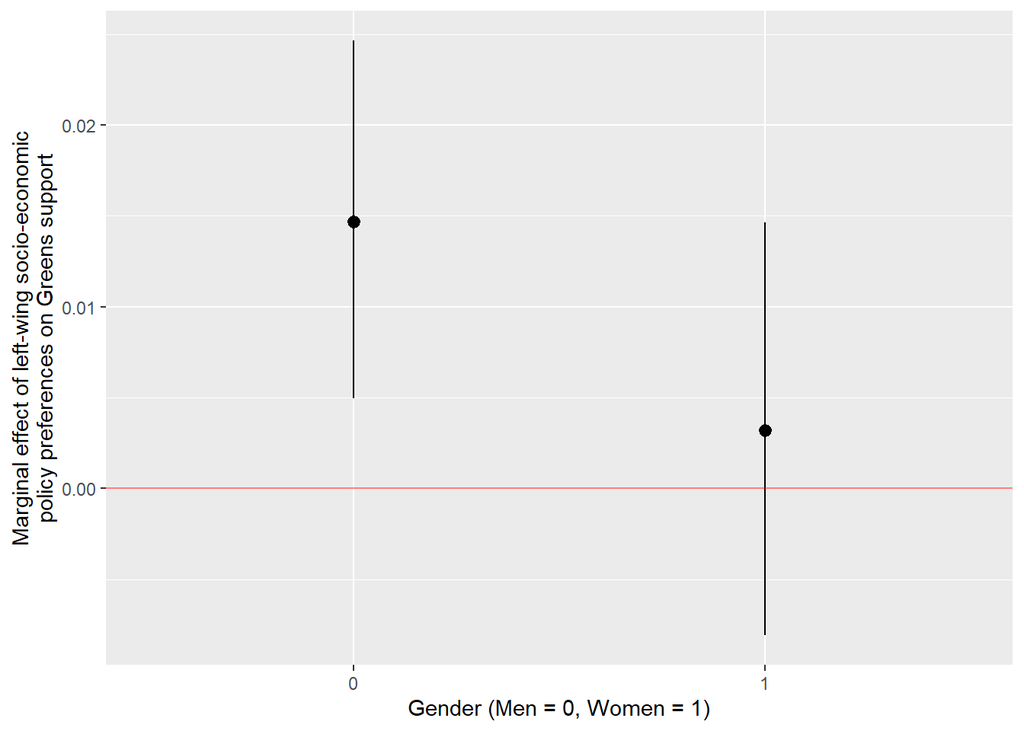

```r
marginaleffects::plot_slopes(logit_brms,
                             variable = "se_self",
                             condition = "fem") +
  ggplot2::geom_hline(yintercept = 0,
                     col = "red",
                     alpha = 0.5) +
  ggplot2::xlab("Gender (Men = 0, Women = 1)") +
  ggplot2::ylab(
    paste(
      "Marginal effect of left-wing socio-economic",
      "policy preferences on Greens support",
      sep = "\n"
    )
  )
```

## Posterior predictive checks

### Distributional congruence

Use posterior predictive checks to test for distributional congruence.

Note that since our outcome is binary, you will learn more from using `type = "bars"` than `type = "dens_overlay"`.

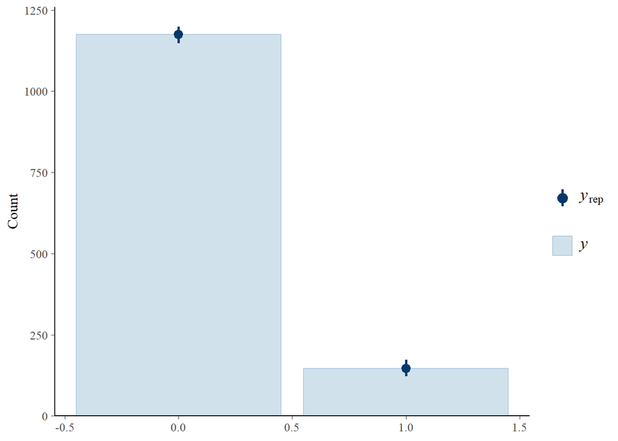

```r
brms::pp_check(logit_brms, ndraws = 1000, type = "bars")
```

What do you conclude? Does our model get the numbers of green voters right?

### Observation-level prediction error

Now turn to the observation-level prediction error. This is best assessed by setting the arguments `type = "error_hist_grouped"` and `group = "vote_greens"`. What can you conclude from this plot?

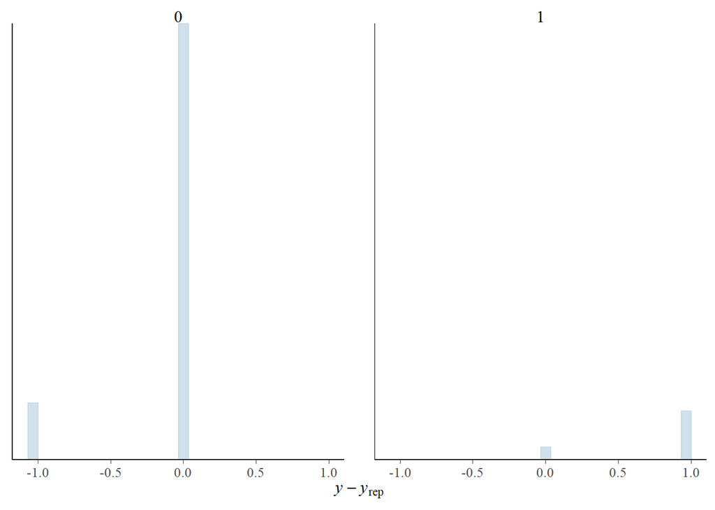

```r
brms::pp_check(logit_brms, ndraws = 1, type = "error_hist_grouped", group = "vote_greens")
```